# 지도학습 모델 개발 가이드라인 적용 예제 (1) Decision Tree

#### 본 문서는 scikit-learn 모듈을 활용한 Decision Tree 알고리즘 적용 예제로, 지도학습 모델 개발 가이드라인에 따라 다음과 같은 순서로 구성됨

> 준비) 모듈 및 데이터 불러오기
> 1. 데이터 분리
> 2. 모델 선택
> 3. 모델 인스턴스화 및 파라미터 설정
> 4. 모델 학습
> 5. 모델 적용
> 6. 모델 평가

## 준비) 모듈 및 데이터 불러오기

Iris 데이터는 데이터 프레임 형태로, 4개의 feature와 "species"라는 label로 구성되어 있음

- feature 부분: ['sepal_length', 'sepal_width', 'petal_length', 'petal_width']
- label 부분: ['species']

```python
## 준비) 모듈 및 데이터 불러오기
import seaborn as sns
import pandas as pd

iris = sns.load_dataset('iris')
print("Data Type of Iris:", type(iris), "\n")
print("Iris Dataset: \n", iris.head())
```

```
Data Type of Iris: <class 'pandas.core.frame.DataFrame'>

Iris Dataset:
    sepal_length  sepal_width  petal_length  petal_width species
0           5.1          3.5           1.4          0.2  setosa
1           4.9          3.0           1.4          0.2  setosa
2           4.7          3.2           1.3          0.2  setosa
3           4.6          3.1           1.5          0.2  setosa
4           5.0          3.6           1.4          0.2  setosa
```

## 1. 데이터 분리

데이터 분리는 크게 다음과 같이 두 단계로 구성됨

(1) feature와 label의 분리

- feature와 label의 분리는 별도로 X와 Y로 별도로 정의해줘도 되고, 데이터 프레임의 슬라이싱을 통해 인덱싱해도 됨

(2) 학습 데이터와 평가 데이터의 분리

- 학습 데이터와 평가 데이터의 분리에는 train_test_split 함수를 사용함
- train_test_split함수는 입력으로 X(학습 데이터), Y(평가 데이터), test_size(평가 데이터의 비율)을 갖음
- test_size를 입력하지 않은 경우에는 기본 값인 0.25로 설정됨

```python
##1 데이터 분리
#(1) feature와 label의 분리
X_iris = iris.iloc[:, :-1]
y_iris = iris['species'] #Y_iris = iris.iloc[:, -1]

#(2) 학습 데이터와 평가 데이터의 분리(test_size = 0.3으로 설정)
from sklearn.model_selection import train_test_split
Train_X, Test_X, Train_y, Test_y = train_test_split(X_iris, y_iris, test_size = 0.3)

print("Train_X's shape:", Train_X.shape, ",\t Train_y's shape:", Train_y.shape)
print("Test_X's shape:", Test_X.shape, ",\t Test_y's shape:", Test_y.shape) # 150*0.3 = 45
print('\nhead of Train_X:\n', Train_X.head())
```

```
Train_X's shape: (105, 4) ,	 Train_y's shape: (105,)
Test_X's shape: (45, 4) ,	 Test_y's shape: (45,)

head of Train_X:
      sepal_length  sepal_width  petal_length  petal_width
104           6.5          3.0           5.8          2.2
54            6.5          2.8           4.6          1.5
23            5.1          3.3           1.7          0.5
125           7.2          3.2           6.0          1.8
83            6.0          2.7           5.1          1.6
```

## 2. 모델 선택 ~ 3. 모델 인스턴스화 및 파라미터 설정

모델 선택은 지도학습에 어떠한 모델을 선택할 것인지를 결정하는 단계로 분석 목적에 맞는 모델을 선택하는 것이 중요함

본 예제에서는 Decision Tree 모델 적용 방법을 소개함

### < Decision Tree 모델 >

- Decision Tree는 sklearn.tree 모듈의 DecisionTreeClassifier 함수를 활용함
- Decision Tree의 주요 파라미터

  - criterion : 분류 규칙에 대한 파라미터로, 두 가지 설정이 있음(기본값은 "gini")

  - "gini" for the Gini impurity and "entropy" for the information gain.

  - 예) tree.DecisionTreeClassifier(criterion="entropy")

  - max_depth : 나무의 최대 깊이에 대한 파라미터로, 정수 값을 입력으로 받음(기본값은 'None')

  - min_samples_split : 노드 당 최소 샘플 수에 대한 파라미터로, 정수 값을 입력으로 받음(기본값은 2)
- 다른 파라미터들에 대한 내용: https://scikit-learn.org/stable/modules/generated/sklearn.tree.DecisionTreeClassifier.html

```python
##3. Decision Tree 모델 인스턴스화 및 파라미터 설정
from sklearn import tree
model_DT = tree.DecisionTreeClassifier(max_depth=3)
```

## 4. 모델 학습

이전 단계에서 인스턴스로 만들어둔 모델을 학습 데이터셋에 대해 학습시키는 단계를 말함

- model.fit(Train_X, Train_y)

```python
##4. Decision Tree 모델 학습
model_DT.fit(Train_X, Train_y)
```

```
DecisionTreeClassifier(class_weight=None, criterion='gini', max_depth=3,
            max_features=None, max_leaf_nodes=None,
            min_impurity_decrease=0.0, min_impurity_split=None,
            min_samples_leaf=1, min_samples_split=2,
            min_weight_fraction_leaf=0.0, presort=False, random_state=None,
            splitter='best')
```

## 5. 모델 적용

학습된 모델을 평가 데이터에 적용하는 단계를 말함

- predicted = model.predict(test_X)

```python
##5. Decision Tree 모델 적용
predicted_DT = model_DT.predict(Test_X)
```

## 6. 모델 평가

모델 적용 결과에 대해 실제 값(test_y)과 예측 값(predicted)을 비교하여 평가하는 단계를 말함

- scikitlearn.metrics 모듈에서 제공하는 주요 모델 평가 함수

  - confusion_matrix(test_y, predicted)

  - classification_report(test_y, predicted)

  - 분류 성능 평가 지표

  - 정확도: accuracy_score(test_y, predicted)

  - 정밀도: precision_score(test_y, predicted)

  - 재현율: recall_score(test_y, predicted)

  - F1점수: f1_score(test_y, predicted)
- 자세한 내용은 https://scikit-learn.org/stable/modules/model_evaluation.html#classification-metrics 에서 확인할 수 있음

```python
##6. Decision Tree 평가
from sklearn.metrics import *
print("\n 1. confusion matrix\n", confusion_matrix(Test_y, predicted_DT))
print("\n 2. classification report\n", classification_report(Test_y, predicted_DT))

res_DT = []
res_DT.append([accuracy_score(Test_y, predicted_DT),
               precision_score(Test_y, predicted_DT, average = "macro"),
               recall_score(Test_y, predicted_DT, average = "macro"),
               f1_score(Test_y, predicted_DT, average = "macro")])

print("3. performance measurements for classification model")
pd.DataFrame(res_DT, columns = ["Accuracy", "Precision", "Recall", "F1-score"], index=['DT'])
```

```
 1. confusion matrix
 [[16  0  0]
 [ 0 15  1]
 [ 0  1 12]]

 2. classification report
               precision    recall  f1-score   support

      setosa       1.00      1.00      1.00        16
  versicolor       0.94      0.94      0.94        16
   virginica       0.92      0.92      0.92        13

   micro avg       0.96      0.96      0.96        45
   macro avg       0.95      0.95      0.95        45
weighted avg       0.96      0.96      0.96        45

3. performance measurements for classification model
```

|  | Accuracy | Precision | Recall | F1-score |
| --- | --- | --- | --- | --- |
| DT | 0.955556 | 0.953526 | 0.953526 | 0.953526 |

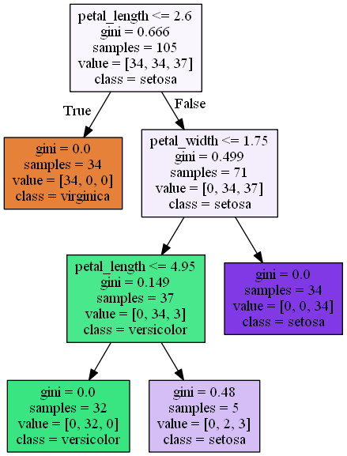

```python
## 7. 결과 해석 및 시각화
import io
import pydot
from IPython.core.display import Image
from sklearn.tree import export_graphviz

def draw_decision_tree(model):
    dot_buf = io.StringIO()
    export_graphviz(model, out_file=dot_buf, feature_names=Train_X.columns,
                    class_names=Train_y.unique(), filled=True)
    graph = pydot.graph_from_dot_data(dot_buf.getvalue())[0]
    image = graph.create_png()
    return Image(image)

draw_decision_tree(model_DT)
```